# Lista 4 - Econometria - ME715

**Questão 1**

Prove que se $X \sim \norm_p(\mu, \Sigma)$, então $(X - \mu)'\Sigma^{-1} (X - \mu) \sim \chi^2_p$

**Resultados auxiliares**

**Definição 1 (Distribuição Chi-quadrado)** Seja $Z_i \overset{i.i.d.}{\sim} \norm(0,1)$, então dizemos que
$$\sum_{i=1}^n Z_i^2 \sim \chi^2_n$$
segue uma distribuição Qui-quadrado com $n$ graus de liberdade.

**Teorema 1** Seja $A$ uma matriz simétrica, então seus autovalores são todos reas.

**Teorema 2 (Teorema Espectral)** Seja $A$ uma matriz quadrada $n \times n$ e simétrica com autovalores reais, então, temos $v^{(1)},\dots,v^{(n)}$ autovetores ortogonais. Além disso, seja $V=(v^{(1)}, \dots, v^{(n)})$ e $D=\operatorname{diag}(\lambda_1, \dots, \lambda_n)$, então
$$A = VDV'$$

Seja $X \sim \norm_p(\mu,\Sigma)$, então

$$\E\left[ \Sigma^{-\frac{1}{2}}(X - \mu) \right] = \Sigma^{-\frac{1}{2}}(\E(X) - \mu)$$
$$\V\left[ \Sigma^{-\frac{1}{2}}(X - \mu) \right] = \Sigma^{-\frac{1}{2}} \V(X) \left( \Sigma^{-\frac{1}{2}} \right)' = \Sigma^{-\frac{1}{2}}\Sigma^{\frac{1}{2}}\Sigma^{\frac{1}{2}}\Sigma^{-\frac{1}{2}} = I$$
Note que a a notação $\Sigma^{-\frac{1}{2}}$ faz sentido, por $\Sigma$ ser uma matriz simétrica (Teorema 2). Logo, $\Sigma^{-\frac{1}{2}} (X - \mu) \sim \norm(\bar0, I)$. Então, pela Definição 1,

$$\left[ \Sigma^{-\frac{1}{2}}(X - \mu) \right]' \Sigma^{-\frac{1}{2}}(X - \mu) = (X - \mu)\Sigma^{-1}(X - \mu) \sim \chi^2_p$$

**Questão 2**

Suponha que ajustou um modelo de regressão e obteve $\beta_1 = 0.56$ e um $\text{p-valor} = 0.086$ para testar $H_0∶ \beta_1 = 0 \;\; V.S. \;\; H_1: \beta_1 \neq 0$. Contudo, você está interessado em testar $H_0∶ \beta_1 = 0 \;\; V.S. \;\; H_1: \beta_1 > 0$, qual seria o p-valor? Rejeitaria $H_0$ a um nível se significância de $5\%$?

Intuição:

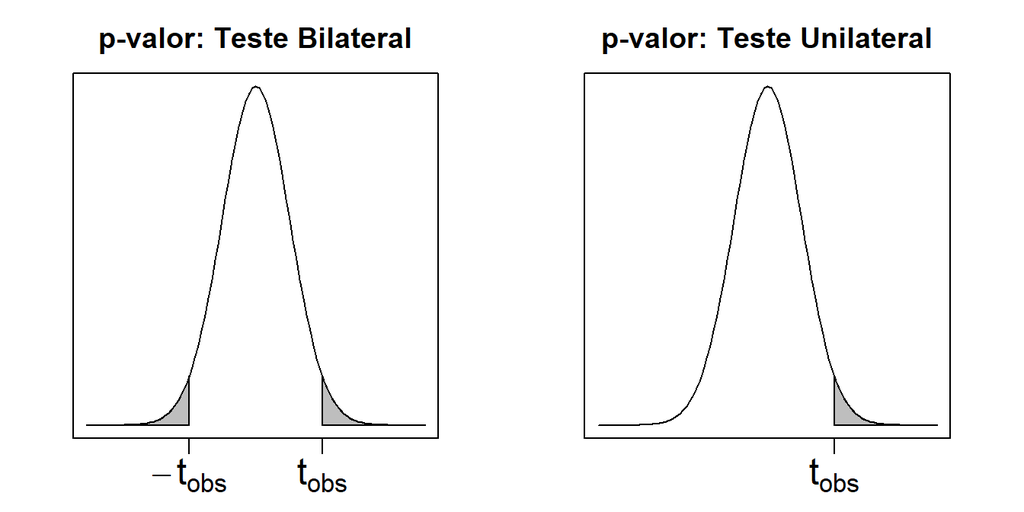

Note, então, que
$$\p_{H_0} (|t| > |t_{obs}|) = 2 \p_{H_0} (t > |t_{obs}|) = 2 \p_{H_0} (t < - |t_{obs}|)$$
Logo, o novo p-valor é de $\frac{0.086}{2} = 0.043$. Portanto, rejeito $H_0$ a favor de $H_1$, a um nível de $5\%$.

**Questão 3**

Um erro comum em muito estudos aplicados é dizer que “aceitamos” $H_0$. Contudo, nós, estatísticos, preferimos dizer “não rejeitamos” $H_0$ e não “aceitamos” $H_0$. Discuta o motivo.

Ao fazer um teste estatístico buscamos evidências contra $H_0$ e em favor de $H_1$, veja que isto não é equivalente, no caso de não encontrar evidência o suficiente, a falar que $H_0$ é verdadeira.

**Questão 4**

O dataset *rdchem* contém informação de 32 empresas da industria química. Entre as informações coletadas, temos: *rdintens* (gastos com pesquisa e desenvolvimento como uma porcentagem das vendas), *sales* (vendas mensuradas em mlhões de dólares) e *profmarg* (lucros como uma porcentagem das vendas). Ajuste um modelo da forma:

$$rdintens = \beta_0 + \beta_1 \log(sales) + \beta_2 profmarg + u$$
assumindo que as hipóteses do modelo linear clássico acontecem.

1. Interprete os coeficientes de $\log(sales)$.
2. Teste a hipóteses de que a intensidade de *P&D* não varia com *sales* contra a alternativa de que *P&D* aumenta com as vendas.
3. Interprete o coeficiente de *profmarg*, ele é economicamente grande?
4. *profmarg* tem um efeito estatisticamente significativo sobre *rdintens*?

**Resultados auxiliares**

Tabela 1: Interpretação dos tipos de modelo

| Modelo | V. Dependente | V. Independente | Interpretação $\beta_1$ |
| --- | --- | --- | --- |
| Nível-Nível | $y$ | $x$ | $\Delta y = \beta_1 \Delta x$ |
| Nível-Log | $y$ | $\log(x)$ | $\Delta y = \frac{\beta_1}{100} \Delta_\% x$ |
| Log-Nível | $\log(y)$ | $x$ | $\Delta_\% y = 100\beta_1 \Delta x$ |
| Log-Log | $\log(y)$ | $\log(x)$ | $\Delta_\% y = \beta_1 \Delta_\% x$ |

1. Interprete os coeficientes de $\log(sales)$.

**R**

```r
# package e banco de dados
require(wooldridge)
data(rdchem)

fit_r <- lm(rdintens ~ log(sales) + profmarg, data = rdchem)
summary(fit_r)
```

```
Call:
lm(formula = rdintens ~ log(sales) + profmarg, data = rdchem)

Residuals:
    Min      1Q  Median      3Q     Max
-2.3016 -1.2707 -0.6895  0.8785  6.0369

Coefficients:
            Estimate Std. Error t value Pr(>|t|)
(Intercept)  0.47225    1.67606   0.282    0.780
log(sales)   0.32135    0.21557   1.491    0.147
profmarg     0.05004    0.04578   1.093    0.283

Residual standard error: 1.839 on 29 degrees of freedom
Multiple R-squared:  0.09847,   Adjusted R-squared:  0.0363
F-statistic: 1.584 on 2 and 29 DF,  p-value: 0.2224
```

**Python**

```python
# packages
import statsmodels.formula.api as smf
import wooldridge as woo
import numpy as np

# lendo dados
rdchem = woo.dataWoo('rdchem')
rdchem = r['rdchem']  # leitura alternativa (direto do R)

# ajustando modelo
fit_py = smf.ols(formula='rdintens ~ np.log(sales) + profmarg', data=rdchem).fit()
print(fit_py.summary())
```

```
                            OLS Regression Results
==============================================================================
Dep. Variable:               rdintens   R-squared:                       0.098
Model:                            OLS   Adj. R-squared:                  0.036
Method:                 Least Squares   F-statistic:                     1.584
Date:                qui, 24 out 2024   Prob (F-statistic):              0.222
Time:                        01:15:22   Log-Likelihood:                -63.333
No. Observations:                  32   AIC:                             132.7
Df Residuals:                      29   BIC:                             137.1
Df Model:                           2
Covariance Type:            nonrobust
=================================================================================
                    coef    std err          t      P>|t|      [0.025      0.975]
---------------------------------------------------------------------------------
Intercept         0.4723      1.676      0.282      0.780      -2.956       3.900
np.log(sales)     0.3213      0.216      1.491      0.147      -0.120       0.762
profmarg          0.0500      0.046      1.093      0.283      -0.044       0.144
==============================================================================
Omnibus:                       15.836   Durbin-Watson:                   1.652
Prob(Omnibus):                  0.000   Jarque-Bera (JB):               17.790
Skew:                           1.430   Prob(JB):                     0.000137
Kurtosis:                       5.272   Cond. No.                         70.6
==============================================================================

Notes:
[1] Standard Errors assume that the covariance matrix of the errors is correctly specified.
```

**Julia**

```julia
using WooldridgeDatasets, DataFrames, Statistics, GLM, Distributions

# dados
rdchem = DataFrame(wooldridge("rdchem"));

fit_julia = lm(@formula(rdintens ~ log(sales) + profmarg), rdchem);
coeficientes = DataFrame(Beta = coefnames(fit_julia), Valor = coef(fit_julia))
```

```
3×2 DataFrame
 Row │ Beta         Valor
     │ String       Float64
─────┼────────────────────────
   1 │ (Intercept)  0.472254
   2 │ log(sales)   0.321348
   3 │ profmarg     0.0500367
```

A cada aumento de $1\%$ na variável *sales* é esperado um aumento de $\frac{\hat\beta_1}{100} = 0.0032$ unidades em *rdintens* (ver Tabela 1).

2. Teste a hipóteses de que a intensidade de *P&D* não varia com *sales* contra a alternativa de que *P&D* aumenta com as vendas.

**R**

```r
fit_r <- lm(rdintens ~ sales, data=rdchem)
summary(fit_r)
```

```
Call:
lm(formula = rdintens ~ sales, data = rdchem)

Residuals:
    Min      1Q  Median      3Q     Max
-2.0531 -1.3234 -0.5280  0.8765  6.1146

Coefficients:
             Estimate Std. Error t value Pr(>|t|)
(Intercept) 3.064e+00  3.689e-01   8.308 2.84e-09 ***
sales       5.318e-05  4.403e-05   1.208    0.237
---
Signif. codes:  0 '***' 0.001 '**' 0.01 '*' 0.05 '.' 0.1 ' ' 1

Residual standard error: 1.86 on 30 degrees of freedom
Multiple R-squared:  0.04638,   Adjusted R-squared:  0.01459
F-statistic: 1.459 on 1 and 30 DF,  p-value: 0.2365
```

**Python**

```python
# ajustando modelo
fit_py = smf.ols(formula='rdintens ~ sales', data=rdchem).fit()
print(fit_py.summary())
```

```
                            OLS Regression Results
==============================================================================
Dep. Variable:               rdintens   R-squared:                       0.046
Model:                            OLS   Adj. R-squared:                  0.015
Method:                 Least Squares   F-statistic:                     1.459
Date:                qui, 24 out 2024   Prob (F-statistic):              0.237
Time:                        01:15:53   Log-Likelihood:                -64.231
No. Observations:                  32   AIC:                             132.5
Df Residuals:                      30   BIC:                             135.4
Df Model:                           1
Covariance Type:            nonrobust
==============================================================================
                 coef    std err          t      P>|t|      [0.025      0.975]
------------------------------------------------------------------------------
Intercept      3.0643      0.369      8.308      0.000       2.311       3.818
sales       5.318e-05    4.4e-05      1.208      0.237   -3.67e-05       0.000
==============================================================================
Omnibus:                       15.661   Durbin-Watson:                   1.684
Prob(Omnibus):                  0.000   Jarque-Bera (JB):               17.224
Skew:                           1.446   Prob(JB):                     0.000182
Kurtosis:                       5.135   Cond. No.                     9.40e+03
==============================================================================

Notes:
[1] Standard Errors assume that the covariance matrix of the errors is correctly specified.
[2] The condition number is large, 9.4e+03. This might indicate that there are
strong multicollinearity or other numerical problems.
```

**Julia**

```julia
using HypothesisTests

fit_julia = lm(@formula(rdintens ~ sales), rdchem);
println(coeftable(fit_julia))
```

```
─────────────────────────────────────────────────────────────────────────────
                  Coef.  Std. Error     t  Pr(>|t|)    Lower 95%    Upper 95%
─────────────────────────────────────────────────────────────────────────────
(Intercept)  3.06429     0.368855    8.31    <1e-08   2.31098     3.81759
sales        5.31799e-5  4.40251e-5  1.21    0.2365  -3.67314e-5  0.000143091
─────────────────────────────────────────────────────────────────────────────
```

3. Interprete o coeficiente de *profmarg*, ele é economicamente grande?

Interpretação: a cada aumento de uma unidade em *profmarg* é esperado, em média e mantendo todos os outros preditores fixos, um aumento de $0.05$ na variável resposta *rdintens*. Não, ele não é economicamente grande, note que não foi significativo.

4. *profmarg* tem um efeito estatisticamente significativo sobre *rdintens*?

Não, o efeito não é estatísticamente significativo.

**Questão 5**

Utilizando o dataset *gpa1*, ajuste um modelo que explique a nota média em um curso superior (*colGPA*) utilizando o número de faltas às aulas por semana (*skipped*), horas de estudo semanais (*hsGPA*) e a nota do *ACT* (equivalente ao vestitubular). Assumindo que as hipóteses do modelo linear clássico acontecem:

1. Encontre um intervalo de confiança $95\%$ para $\beta_{hsGPA}$.
2. Teste $H_0∶ \beta_{hsGPA} = 0.4 \;\; V.S. \;\; H_1∶ \beta_{hsGPA} \neq 0.4$.
3. Você pode rejeitar a hipóteses $H_0: \beta_{hsGPA} = 1$ contra a alternativa bilateral ($H_1: \beta_{hsGPA} \neq 1$)?
4. Teste a hipótese nula de que, uma vez tendo sido controlado as horas de estudo semanais, o efeito de *skipped* e *ACT* sobre *colGPA* são, conjuntamente, nulos.
1. Encontre um intervalo de confiança $95\%$ para $\beta_{hsGPA}$.

**R**

```r
model_r <- lm(colGPA ~ skipped + hsGPA + ACT, data = gpa1)  # ajustando modelo
confint(model_r, level = 0.95)  # intervalo de confianca
```

```
                   2.5 %      97.5 %
(Intercept)  0.733929519  2.04517814
skipped     -0.134523444 -0.03170283
hsGPA        0.226581851  0.59705049
ACT         -0.006171074  0.03561154
```

**Python**

```python
# lendo dados
gpa1 = woo.dataWoo('gpa1')
gpa1 = r['gpa1']  # leitura alternativa (direto do R)

# ajustando modelo
model_py = smf.ols(formula='colGPA ~ skipped + hsGPA + ACT', data=gpa1).fit()
ic = model_py.conf_int()
ic.columns = ['2.5%', '97.5%']
print(ic)
```

```
               2.5%     97.5%
Intercept  0.733930  2.045178
skipped   -0.134523 -0.031703
hsGPA      0.226582  0.597050
ACT       -0.006171  0.035612
```

**Julia**

```julia
gpa1 = DataFrame(wooldridge("gpa1"));
model_julia = lm(@formula(colGPA ~ skipped + hsGPA + ACT), gpa1);
results = DataFrame(
    Term = coefnames(model_julia),
    LowerCI = confint(model_julia)[:, 1],
    UpperCI = confint(model_julia)[:, 2]
)
```

```
4×3 DataFrame
 Row │ Term         LowerCI      UpperCI
     │ String       Float64      Float64
─────┼──────────────────────────────────────
   1 │ (Intercept)   0.73393      2.04518
   2 │ skipped      -0.134523    -0.0317028
   3 │ hsGPA         0.226582     0.59705
   4 │ ACT          -0.00617107   0.0356115
```

2. Teste $H_0∶ \beta_{hsGPA} = 0.4 \;\; V.S. \;\; H_1∶ \beta_{hsGPA} \neq 0.4$.

**R**

```r
coef_hsGPA <- coef(model_r)['hsGPA']
ep_hsGPA <- summary(model_r)$coefficients['hsGPA', 'Std. Error']

valor_t <- (coef_hsGPA - 0.4) / ep_hsGPA

gl <- model_r$df.residual
p_valor <- 2*pt(-abs(valor_t), gl)  # P(|t| > |t_obs|) = 2 P(t < -|t_obs|)

cat(paste0('Valor t:', round(valor_t, 4), '\n', 'p-valor:', round(p_valor, 4)))
```

```
Valor t:0.1261
p-valor:0.8998
```

**Python**

```python
import scipy.stats as stats

coef_hsGPA = model_py.params['hsGPA']
ep_hsGPA = model_py.bse['hsGPA']

valor_t = (coef_hsGPA - 0.4) / ep_hsGPA

gl = model_py.df_resid
p_valor = 2 * stats.t.cdf(-abs(valor_t), gl)  # P(|t| > |t_obs|) = 2 P(t < -|t_obs|)

print(f'Valor t: {valor_t:4f} \np-valor: {p_valor:4f}')
```

```
Valor t: 0.126141
p-valor: 0.899805
```

**Julia**

```julia
coef_hsGPA = coef(model_julia)[3];
ep_hsGPA = stderror(model_julia)[3];

valor_t = (coef_hsGPA - 0.4) / ep_hsGPA;

gl = 137;

p_valor = 2 * cdf(TDist(gl), -abs(valor_t))
```

```
0.8998051414602578
```

3. Você pode rejeitar a hipóteses $H_0: \beta_{hsGPA} = 1$ contra a alternativa bilateral ($H_1: \beta_{hsGPA} \neq 1$)?

**R**

```r
valor_t <- (coef_hsGPA - 1) / ep_hsGPA

gl <- model_r$df.residual
p_valor <- 2*pt(-abs(valor_t), gl)  # P(|t| > |t_obs|) = 2 P(t < -|t_obs|)

cat(paste0('Valor t:', round(valor_t, 4), '\n', 'p-valor:', round(p_valor, 4)))
```

```
Valor t:-6.279
p-valor:0
```

**Python**

```python
coef_hsGPA = model_py.params['hsGPA']
ep_hsGPA = model_py.bse['hsGPA']

valor_t = (coef_hsGPA - 1) / ep_hsGPA

gl = model_py.df_resid
p_valor = 2 * stats.t.cdf(-abs(valor_t), gl)  # P(|t| > |t_obs|) = 2 P(t < -|t_obs|)

print(f'Valor t: {valor_t:4f} \np-valor: {p_valor:4f}')
```

```
Valor t: -6.279037
p-valor: 0.000000
```

**Julia**

```julia
coef_hsGPA = coef(model_julia)[3];
ep_hsGPA = stderror(model_julia)[3];

valor_t = (coef_hsGPA - 1) / ep_hsGPA
```

```
-6.279036501519401
```

```julia
gl = 137;

p_valor = 2 * cdf(TDist(gl), -abs(valor_t))
```

```
4.204251632295657e-9
```

4. Teste a hipótese nula de que, uma vez tendo sido controlado as horas de estudo semanais, o efeito de *skipped* e *ACT* sobre *colGPA* são, conjuntamente, nulos.

Hipóteses:
$$H_0: \beta_{skipped} = \beta_{ACT} = 0 \quad V.S. \quad H_1: \beta_{skipped} \neq 0 \text{ ou } \beta_{ACT} \neq 0$$

A estatística do teste é dada por:

$$F = \frac{(SQR_r - SQR_i)/q}{SQR_i/(n-(k+1))} \overset{H_0}{\sim} F_{q, n-(k+1)}$$
onde $SQR_i$ é a soma dos resíduos do modelo irrestrito (completo) e $SQR_r$ é a soma dos resíduos do modelo reduzido, isto é, o modelo irrestrito sem as preditoras que se deseja testar.

**R**

```r
# Ajustando modelo completo e reduzido
modelo_completo <- lm(colGPA ~ skipped + hsGPA + ACT, data = gpa1)
modelo_reduzido <- lm(colGPA ~ hsGPA, data = gpa1)
anova(modelo_reduzido, modelo_completo)
```

```
Analysis of Variance Table

Model 1: colGPA ~ hsGPA
Model 2: colGPA ~ skipped + hsGPA + ACT
  Res.Df    RSS Df Sum of Sq      F   Pr(>F)
1    139 16.071
2    137 14.873  2    1.1981 5.5179 0.004957 **
---
Signif. codes:  0 '***' 0.001 '**' 0.01 '*' 0.05 '.' 0.1 ' ' 1
```

**Python**

```python
import statsmodels.api as sm

# ajustando modelo completo e reduzido
modelo_completo = smf.ols(formula='colGPA ~ skipped + hsGPA + ACT', data=gpa1).fit()
modelo_reduzido = smf.ols(formula='colGPA ~ hsGPA', data=gpa1).fit()
sm.stats.anova_lm(modelo_reduzido, modelo_completo)
```

```
   df_resid        ssr  df_diff   ss_diff         F    Pr(>F)
0     139.0  16.071039      0.0       NaN       NaN       NaN
1     137.0  14.872966      2.0  1.198073  5.517931  0.004957
```

**Julia**

```julia
modelo_completo = lm(@formula(colGPA ~ skipped + hsGPA + ACT), gpa1);
modelo_reduzido = lm(@formula(colGPA ~ hsGPA), gpa1);
ftest(modelo_reduzido.model, modelo_completo.model)
```

```
F-test: 2 models fitted on 141 observations
────────────────────────────────────────────────────────────────
     DOF  ΔDOF      SSR     ΔSSR      R²     ΔR²      F*   p(>F)
────────────────────────────────────────────────────────────────
[1]    3        16.0710           0.1719
[2]    5     2  14.8730  -1.1981  0.2336  0.0617  5.5179  0.0050
────────────────────────────────────────────────────────────────
```

**Questão 6**

Utilize o conjunto de dados *wage2* e ajuste a regressão
$$\log(wage) = \beta_0 + \beta_1 educ + \beta_2 exper + \beta_3 tenure + u$$
em que *wage* é o salario-hora em dolares, *educ* são os anos de educação formal, *exper* são os anos de experiência no mercado de trabalho e *tenure* são os anos de permanencia no emprego atual.

1. Teste a hipótede de significância geral do modelo.
2. Teste a hipótese de que um ano a mais de experiência no mercado de trabalho tem o mesmo efeito sobre $\log(wage)$ que mais um ano de permanencia no emprego atual.
3. Teste a hipótese de que, controlado o número de anos de permanencia no emprego (*tenure*), *educ* e *exper* não tem efeito nenhum sobre $\log(wage)$.
1. Teste a hipótese de significância geral do modelo.

**R**

```r
# Ajustar o modelo de regressão
fit_r <- lm(log(wage) ~ educ + exper + tenure, data = wage2)
summary(fit_r)
```

```
Call:
lm(formula = log(wage) ~ educ + exper + tenure, data = wage2)

Residuals:
    Min      1Q  Median      3Q     Max
-1.8282 -0.2401  0.0203  0.2569  1.3400

Coefficients:
            Estimate Std. Error t value Pr(>|t|)
(Intercept) 5.496696   0.110528  49.731  < 2e-16 ***
educ        0.074864   0.006512  11.495  < 2e-16 ***
exper       0.015328   0.003370   4.549 6.10e-06 ***
tenure      0.013375   0.002587   5.170 2.87e-07 ***
---
Signif. codes:  0 '***' 0.001 '**' 0.01 '*' 0.05 '.' 0.1 ' ' 1

Residual standard error: 0.3877 on 931 degrees of freedom
Multiple R-squared:  0.1551,    Adjusted R-squared:  0.1524
F-statistic: 56.97 on 3 and 931 DF,  p-value: < 2.2e-16
```

**Python**

```python
wage2 = woo.dataWoo('wage2')
wage2 = r['wage2']  # leitura alternativa (direto do R)

fit_py = smf.ols('np.log(wage) ~ educ + exper + tenure', data=wage2).fit()
fit_py.summary()
```

OLS Regression Results

| Dep. Variable: | np.log(wage) | R-squared: | 0.155 |
| --- | --- | --- | --- |
| Model: | OLS | Adj. R-squared: | 0.152 |
| Method: | Least Squares | F-statistic: | 56.97 |
| Date: | qui, 24 out 2024 | Prob (F-statistic): | 8.12e-34 |
| Time: | 01:16:08 | Log-Likelihood: | -438.84 |
| No. Observations: | 935 | AIC: | 885.7 |
| Df Residuals: | 931 | BIC: | 905.0 |
| Df Model: | 3 |  |  |
| Covariance Type: | nonrobust |  |  |

|  | coef | std err | t | P>\|t\| | [0.025 | 0.975] |
| --- | --- | --- | --- | --- | --- | --- |
| Intercept | 5.4967 | 0.111 | 49.731 | 0.000 | 5.280 | 5.714 |
| educ | 0.0749 | 0.007 | 11.495 | 0.000 | 0.062 | 0.088 |
| exper | 0.0153 | 0.003 | 4.549 | 0.000 | 0.009 | 0.022 |
| tenure | 0.0134 | 0.003 | 5.170 | 0.000 | 0.008 | 0.018 |

| Omnibus: | 20.917 | Durbin-Watson: | 1.769 |
| --- | --- | --- | --- |
| Prob(Omnibus): | 0.000 | Jarque-Bera (JB): | 30.558 |
| Skew: | -0.214 | Prob(JB): | 2.31e-07 |
| Kurtosis: | 3.775 | Cond. No. | 170. |

Notes:  
[1] Standard Errors assume that the covariance matrix of the errors is correctly specified.

**Julia**

```julia
wage2 = DataFrame(wooldridge("wage2"));
fit_julia = lm(@formula(log(wage) ~ educ + exper + tenure), wage2);
ftest(fit_julia.model)
```

```
F-test against the null model:
F-statistic: 56.97 on 935 observations and 3 degrees of freedom, p-value: <1e-33
```

2. Teste a hipótese de que um ano a mais de experiência no mercado de trabalho tem o mesmo efeito sobre $\log(wage)$ que mais um ano de permanencia no emprego atual.

**R**

```r
require(car)

fit_r <- lm(log(wage) ~ educ + exper + tenure, data=wage2)
linearHypothesis(fit_r, 'exper - tenure = 0')
```

```
Linear hypothesis test

Hypothesis:
exper - tenure = 0

Model 1: restricted model
Model 2: log(wage) ~ educ + exper + tenure

  Res.Df    RSS Df Sum of Sq      F Pr(>F)
1    932 139.99
2    931 139.96  1  0.025502 0.1696 0.6805
```

**Python**

```python
fit_py = smf.ols(formula='np.log(wage) ~ educ + exper + tenure', data=wage2).fit()
restricao = 'exper - tenure = 0'
resultado = fit_py.wald_test(restricao)
print(resultado)
```

```
<F test: F=array([[0.16963746]]), p=0.6805290172334271, df_denom=931, df_num=1>
```

**Julia**

```julia
# function wald_test(;Sigma, b, Terms = nothing, L = nothing, H0 = nothing, df = nothing, print_result = true)
#     if Terms == nothing && L == nothing
#         error("One of the arguments Terms or L must be used.")
#     end
#     if Terms != nothing && L != nothing
#         error("Only one of the arguments Terms or L must be used.")
#     end
#     if Terms == nothing
#         w = size(L)[1]
#         Terms = (1:length(b))[(sum(L, dims = 1) .> 0)[1, :]]
#     else
#         w = length(Terms)
#     end
#     if H0 == nothing
#         H0 = fill(0, w)
#     end
#     if w != length(H0)
#         error("Vectors of tested coefficients and of null hypothesis have different lengths\n")
#     end
#     if L == nothing
#         L = fill(0, w, length(b))
#         for i in 1:w
#             L[i, Terms[i]] = 1
#         end
#     end
#     f = L * b
#     V = Sigma
#     mat = inv(L * V * L')
#     statistic = (f - H0)' * mat * (f - H0)
#     p = ccdf(Chisq(w), statistic)
#     if df == nothing
#         res = Dict("chi2" => (chi2 = statistic, df = w, P = p))
#     else
#         fstat = statistic/size(L)[1]
#         df1 = size(L)[1]
#         df2 = df
#         res = Dict("chi2" => (chi2 = statistic, df = w, P = p),
#             "Ftest" => (Fstat = fstat, df1 = df1, df2 = df2, P = ccdf(FDist(df1, df2), fstat)))
#     end
#
#     if print_result == true
#         println("Wald test:\n", "----------\n\n", "Chi-squared test:\n",
#             "X2 = ", res["chi2"].chi2, ", df = ", res["chi2"].df, ", P(> X2) = ", res["chi2"].P)
#         if df != nothing
#             println("\nF test:\n",
#             "W = ", res["Ftest"].Fstat, ", df1 = ", res["Ftest"].df1, ", df2 = ", res["Ftest"].df2, ", P(> W) = ", res["Ftest"].P)
#         end
#     end
#
#     return (Sigma = Sigma, b = b, Terms = Terms, H0 = H0, L = L, result = res, df = df)
# end
#
# # include("wald_test.jl")
# fit_julia_completo = lm(@formula(log(wage) ~ educ + exper + tenure), wage2);
# fit_julia_reduzido = lm(@formula(log(wage) ~ educ + (exper + tenure), wage2);
# wald_test(Sigma = vcov(fit_julia_completo), b = coef(fit_julia_reduzido), Terms = 2:3)
# ftest(fit_julia_completo.model, fit_julia_reduzido.model)
```

3. Teste a hipótese de que, controlado o número de anos de permanencia no emprego (*tenure*), *educ* e *exper* não tem efeito nenhum sobre $\log(wage)$.

**R**

```r
mod_completo <- lm(log(wage) ~ educ + exper + tenure, data=wage2)
mod_reduzido <- lm(log(wage) ~ tenure, data=wage2)
anova(mod_reduzido, mod_completo)
```

```
Analysis of Variance Table

Model 1: log(wage) ~ tenure
Model 2: log(wage) ~ educ + exper + tenure
  Res.Df    RSS Df Sum of Sq     F    Pr(>F)
1    933 159.93
2    931 139.96  2    19.973 66.43 < 2.2e-16 ***
---
Signif. codes:  0 '***' 0.001 '**' 0.01 '*' 0.05 '.' 0.1 ' ' 1
```

**Python**

```python
mod_completo = smf.ols(formula='np.log(wage) ~ educ + exper + tenure', data=wage2).fit()
mod_reduzido = smf.ols(formula='np.log(wage) ~ tenure', data=wage2).fit()
sm.stats.anova_lm(mod_reduzido, mod_completo)
```

```
   df_resid         ssr  df_diff   ss_diff          F        Pr(>F)
0     933.0  159.934322      0.0       NaN        NaN           NaN
1     931.0  139.960963      2.0  19.97336  66.429944  1.074911e-27
```

**Julia**

```julia
fit_julia_completo = lm(@formula(log(wage) ~ educ + exper + tenure), wage2);
fit_julia_reduzido = lm(@formula(log(wage) ~ tenure), wage2);
ftest(fit_julia_completo.model, fit_julia_reduzido.model)
```

```
F-test: 2 models fitted on 935 observations
───────────────────────────────────────────────────────────────────
     DOF  ΔDOF       SSR     ΔSSR      R²      ΔR²       F*   p(>F)
───────────────────────────────────────────────────────────────────
[1]    5        139.9610           0.1551
[2]    3    -2  159.9343  19.9734  0.0345  -0.1206  66.4299  <1e-26
───────────────────────────────────────────────────────────────────
```

**Questão 7**

Utilize o conjunto de dados *htv* e ajuste a regressão
$$educ = \beta_0 + \beta_1 motheduc + \beta_2 fatheduc + \beta_3 abil + \beta_4 abil^2 + u$$

1. Teste a hipóteses de que a influencia que *motheduc* e *fatheduc* exercem sobre *educ* é a mesma.
2. Teste a hipótese de que *educ* está linearmente relacionado com *abil* contra a alternativa que diz que a relação é quadrática.
3. Um colega de trabalho diz que o modelo $educ = \beta_0 + \beta_1 abil + \beta_2 abil^2 + u$ é suficiente, e que tanto *motheduc* e *fatheduc* não são importantes para o modelos. Faça um teste de hipóteses para rejeitar ou não rejeitar a hipótese do seu colega.
1. Teste a hipóteses de que a influencia que *motheduc* e *fatheduc* exercem sobre *educ* é a mesma.

**R**

```r
# require(car)

fit_r <- lm(educ ~ motheduc + fatheduc + abil + I(abil^2), data=htv)
linearHypothesis(fit_r, 'motheduc - fatheduc = 0')
```

```
Linear hypothesis test

Hypothesis:
motheduc - fatheduc = 0

Model 1: restricted model
Model 2: educ ~ motheduc + fatheduc + abil + I(abil^2)

  Res.Df    RSS Df Sum of Sq      F  Pr(>F)
1   1226 3796.8
2   1225 3785.2  1    11.578 3.7468 0.05314 .
---
Signif. codes:  0 '***' 0.001 '**' 0.01 '*' 0.05 '.' 0.1 ' ' 1
```

**Python**

```python
htv = woo.dataWoo('htv')
htv = r['htv']  # leitura alternativa (direto do R)

fit_py = smf.ols('educ ~ motheduc + fatheduc + abil + I(abil**2)', data=htv).fit()
restricao = 'motheduc - fatheduc = 0'
resultado = fit_py.wald_test(restricao)

print(resultado)
```

```
<F test: F=array([[3.74676464]]), p=0.05313970412965828, df_denom=1.22e+03, df_num=1>
```

2. Teste a hipótese de que *educ* está linearmente relacionado com *abil* contra a alternativa que diz que a relação é quadrática.

**R**

```r
fit_completo <- lm(educ ~ motheduc + fatheduc + abil + I(abil^2), data=htv)
fit_reduzido <- lm(educ ~ motheduc + fatheduc + abil, data=htv)
anova(fit_completo, fit_reduzido)
```

```
Analysis of Variance Table

Model 1: educ ~ motheduc + fatheduc + abil + I(abil^2)
Model 2: educ ~ motheduc + fatheduc + abil
  Res.Df    RSS Df Sum of Sq     F    Pr(>F)
1   1225 3785.2
2   1226 3900.0 -1   -114.73 37.13 1.478e-09 ***
---
Signif. codes:  0 '***' 0.001 '**' 0.01 '*' 0.05 '.' 0.1 ' ' 1
```

**Python**

```python
fit_completo = smf.ols(formula='educ ~ motheduc + fatheduc + abil + I(abil**2)',
                       data=htv).fit()
fit_reduzido = smf.ols(formula='educ ~ motheduc + fatheduc + abil', data=htv).fit()
sm.stats.anova_lm(fit_reduzido, fit_completo)
```

```
   df_resid          ssr  df_diff     ss_diff          F        Pr(>F)
0    1226.0  3899.972622      0.0         NaN        NaN           NaN
1    1225.0  3785.242616      1.0  114.730006  37.129524  1.478065e-09
```

**Julia**

```julia
htv = DataFrame(wooldridge("htv"));
fit_julia_completo = lm(@formula(educ ~ motheduc + fatheduc + abil + abil^2), htv);
fit_julia_reduzido = lm(@formula(educ ~ motheduc + fatheduc + abil), htv);
ftest(fit_julia_completo.model, fit_julia_reduzido.model)
```

```
F-test: 2 models fitted on 1230 observations
─────────────────────────────────────────────────────────────────────
     DOF  ΔDOF        SSR      ΔSSR      R²      ΔR²       F*   p(>F)
─────────────────────────────────────────────────────────────────────
[1]    6        3785.2426            0.4444
[2]    5    -1  3899.9726  114.7300  0.4275  -0.0168  37.1295  <1e-08
─────────────────────────────────────────────────────────────────────
```

3. Um colega de trabalho diz que o modelo $educ = \beta_0 + \beta_1 abil + \beta_2 abil^2 +𝑢$ é suficiente, e que tanto *motheduc* e *fatheduc* não são importantes para o modelos. Faça um teste de hipóteses para rejeitar ou não rejeitar a hipótese do seu colega.

**R**

```r
fit_completo <- lm(educ ~ motheduc + fatheduc + abil + I(abil^2), data=htv)
fit_reduzido <- lm(educ ~ abil + I(abil^2), data=htv)
anova(fit_completo, fit_reduzido)
```

```
Analysis of Variance Table

Model 1: educ ~ motheduc + fatheduc + abil + I(abil^2)
Model 2: educ ~ abil + I(abil^2)
  Res.Df    RSS Df Sum of Sq      F    Pr(>F)
1   1225 3785.2
2   1227 4287.9 -2   -502.63 81.333 < 2.2e-16 ***
---
Signif. codes:  0 '***' 0.001 '**' 0.01 '*' 0.05 '.' 0.1 ' ' 1
```

**Python**

```python
fit_completo = smf.ols(formula='educ ~ motheduc + fatheduc + abil + I(abil**2)',
                       data=htv).fit()
fit_reduzido = smf.ols(formula='educ ~ abil + I(abil**2)', data=htv).fit()
sm.stats.anova_lm(fit_reduzido, fit_completo)
```

```
   df_resid          ssr  df_diff     ss_diff          F        Pr(>F)
0    1227.0  4287.877365      0.0         NaN        NaN           NaN
1    1225.0  3785.242616      2.0  502.634749  81.332642  6.822776e-34
```

**Julia**

```julia
fit_julia_completo = lm(@formula(educ ~ motheduc + fatheduc + abil + abil^2), htv);
fit_julia_reduzido = lm(@formula(educ ~ abil + abil^2), htv);
ftest(fit_julia_completo.model, fit_julia_reduzido.model)
```

```
F-test: 2 models fitted on 1230 observations
─────────────────────────────────────────────────────────────────────
     DOF  ΔDOF        SSR      ΔSSR      R²      ΔR²       F*   p(>F)
─────────────────────────────────────────────────────────────────────
[1]    6        3785.2426            0.4444
[2]    4    -2  4287.8774  502.6347  0.3706  -0.0738  81.3326  <1e-33
─────────────────────────────────────────────────────────────────────
```